# EDA for flights data

Alexander Kolupaev

11/04/2017

### About

The data set contains information flight delays and performance for domestic carriers in the United States. The year of 2016 is considered in the analysis. The data set can be accessed from [RITA](https://www.transtats.bts.gov/OT_Delay/OT_DelayCause1.asp).

I will only focus on the 4 biggest airlines with combined market share of about [70%](https://www.statista.com/statistics/250577/domestic-market-share-of-leading-us-airlines/). Those are:

- Southwest
- Delta
- American
- United

### Load and Inspect

First, load and inspect the data. There are 12217 observations and 22 variables:

```
## 'data.frame':    12217 obs. of  22 variables:
##  $ year               : int  2016 2016 2016 2016 2016 2016 2016 2016 2016 2016 ...
##  $ X.month            : int  1 1 1 1 1 1 1 1 1 1 ...
##  $ carrier            : Factor w/ 12 levels "AA","AS","B6",..: 1 1 1 1 1 1 1 1 1 1 ...
##  $ carrier_name       : Factor w/ 12 levels "Alaska Airlines Inc.",..: 2 2 2 2 2 2 2 2 2 2 ...
##  $ airport            : Factor w/ 313 levels "ABE","ABI","ABQ",..: 81 87 272 161 278 223 235 289 171 188 ...
##  $ airport_name       : Factor w/ 313 levels "Aberdeen, SD: Aberdeen Regional",..: 72 78 274 210 262 58 234 284 177 223 ...
##  $ arr_flights        : num  11956 588 607 1595 327 ...
##  $ arr_del15          : num  1534 98 92 335 59 ...
##  $ carrier_ct         : num  507.3 34.7 35.5 117 23.7 ...
##  $ X.weather_ct       : num  39.83 4.71 5.4 10.26 1.47 ...
##  $ nas_ct             : num  452.6 19.8 23.6 117.7 14.5 ...
##  $ security_ct        : num  4.72 0.32 0 0.83 0.06 0.99 0.12 0 1.29 1.09 ...
##  $ late_aircraft_ct   : num  529.5 38.5 27.5 89.2 19.3 ...
##  $ arr_cancelled      : num  201 13 12 137 0 98 86 8 74 55 ...
##  $ arr_diverted       : num  9 2 2 6 0 2 3 1 2 2 ...
##  $ X.arr_delay        : num  106950 5170 4485 23698 2276 ...
##  $ X.carrier_delay    : num  50027 1754 1857 9681 985 ...
##  $ weather_delay      : num  2842 312 198 1592 94 ...
##  $ nas_delay          : num  13913 655 715 4371 373 ...
##  $ security_delay     : num  167 16 0 18 5 242 5 0 36 35 ...
##  $ late_aircraft_delay: num  40001 2433 1715 8036 819 ...
##  $ X                  : logi  NA NA NA NA NA NA ...
```

## Reshaping

I am only interested in 4 airlines. Moreover, I only want to look at delays due to the carrier. Therefore I only leave variables and airlines of interest. Variables include:

- total flights (arr_flights)
- flights delayed (arr_del15)
- total minutes delayed (arr_delay)
- total minutes delayed because of carrier (carrier_delay)

```
##
##   1   2   3   4   5   6   7   8   9  10  11  12
## 415 414 411 411 404 416 408 419 417 417 416 420
```

```
## 'data.frame':    4968 obs. of  8 variables:
##  $ year         : int  2016 2016 2016 2016 2016 2016 2016 2016 2016 2016 ...
##  $ arr_del15    : num  1534 98 92 335 59 ...
##  $ arr_flights  : num  11956 588 607 1595 327 ...
##  $ month        : int  1 1 1 1 1 1 1 1 1 1 ...
##  $ carrier      : Factor w/ 4 levels "AA","DL","UA",..: 1 1 1 1 1 1 1 1 1 1 ...
##  $ arr_delay    : num  106950 5170 4485 23698 2276 ...
##  $ carrier_delay: num  50027 1754 1857 9681 985 ...
##  $ date         : Date, format: "2016-01-01" "2016-01-01" ...
```

```
##
##   AA   DL   UA   WN
## 1103 1780 1046 1039
```

```
## 'data.frame':    4968 obs. of  8 variables:
##  $ year         : int  2016 2016 2016 2016 2016 2016 2016 2016 2016 2016 ...
##  $ arr_del15    : num  1534 98 92 335 59 ...
##  $ arr_flights  : num  11956 588 607 1595 327 ...
##  $ month        : int  1 1 1 1 1 1 1 1 1 1 ...
##  $ carrier      : Factor w/ 4 levels "AA","DL","UA",..: 1 1 1 1 1 1 1 1 1 1 ...
##  $ arr_delay    : num  106950 5170 4485 23698 2276 ...
##  $ carrier_delay: num  50027 1754 1857 9681 985 ...
##  $ date         : Date, format: "2016-01-01" "2016-01-01" ...
```

### Summarise

I group by month and carrier and calculate two ratios:

- ratio of flights delayed
- share of delay because of carrier

### Plotting

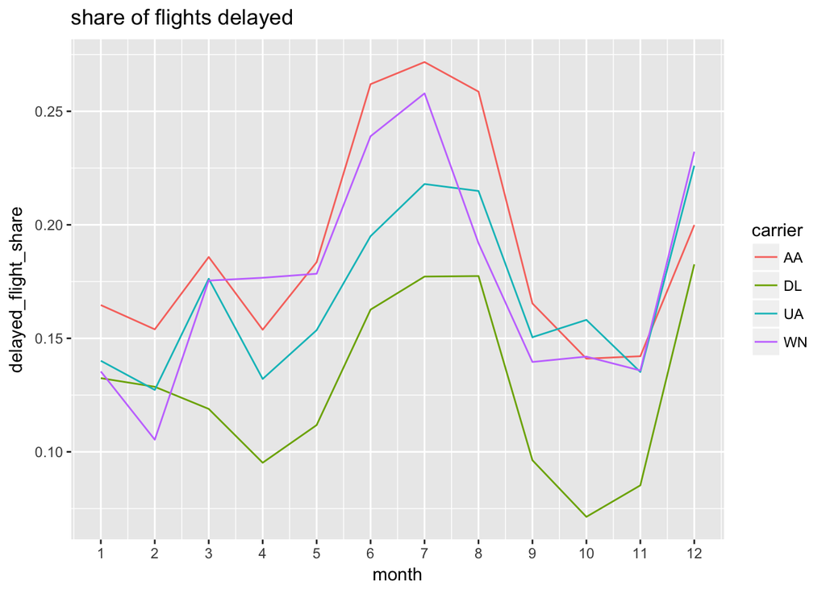

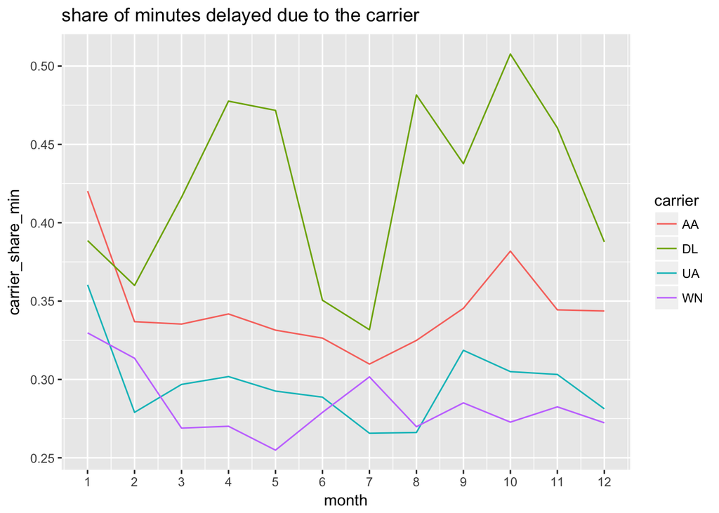